# Thera_Bank Project_Final

### Observations on Total_Amt_Chng_Q4_Q1

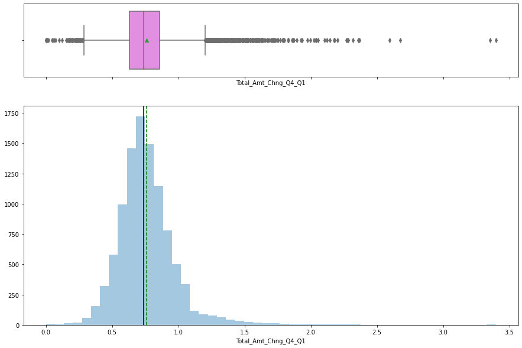

```python
histogram_boxplot(df['Total_Amt_Chng_Q4_Q1'])
plt.savefig('Plt_TAC.png')
plt.show()
```

### Observations on Total_Trans_Amt

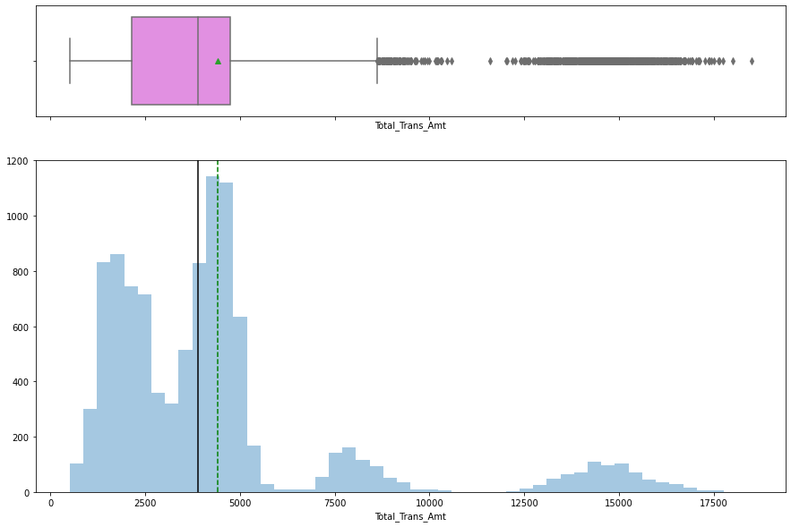

```python
histogram_boxplot(df['Total_Trans_Amt'])
plt.savefig('Plt_TTA.png')
plt.show()
```

- This plot also speaks to a wide range in transaction amount hence acoounting for the outlier presence seen here
- The distribution of the total transaction amoutn appears trimodal in nature
- The average transaction amount was 4404 with 75% of the customers dealing a total transaction amount of $4741 or less

### Observations on Total_Trans_Ct

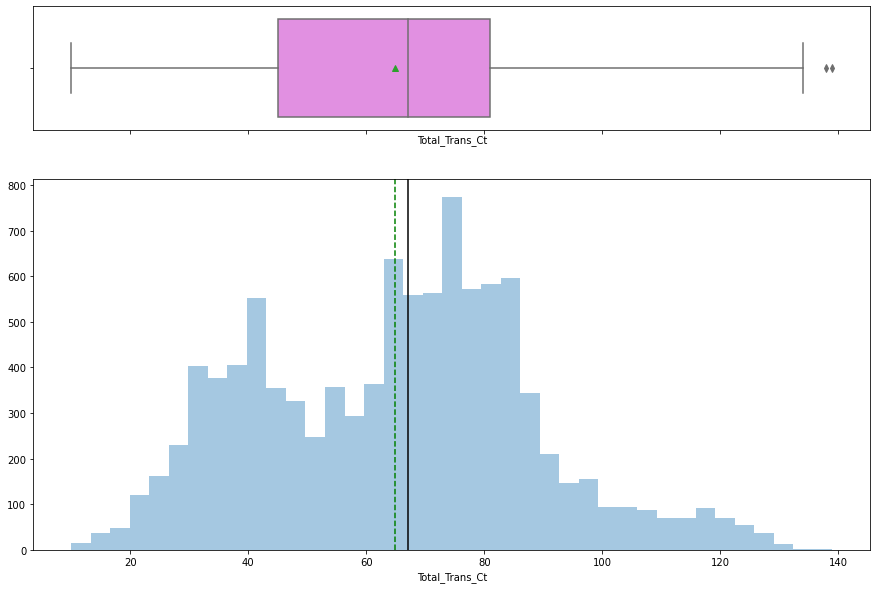

```python
histogram_boxplot(df['Total_Trans_Ct'])
plt.savefig('Plt_TTC.png')
plt.show()
```

- The average transaction count is approx. 65 with the highest at 139.
- We have outliers present here obviously as a result of the wide range existing
- 75% of the customers registered a count of 81 or less

### Observations on Total_Ct_Chng_Q4_Q1

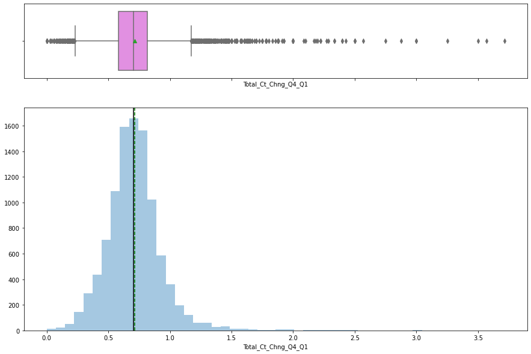

```python
histogram_boxplot(df['Total_Ct_Chng_Q4_Q1'])
plt.savefig('Plt_TCC.png')
plt.show()
```

- The total count change is a normal ditribution.
- Tremendous presence of outliers.This will be treated as we proceed.
- The total count change stood at 0.71(71%) from Q4 to Q1

### Observations on Avg_Utilization_Ratio

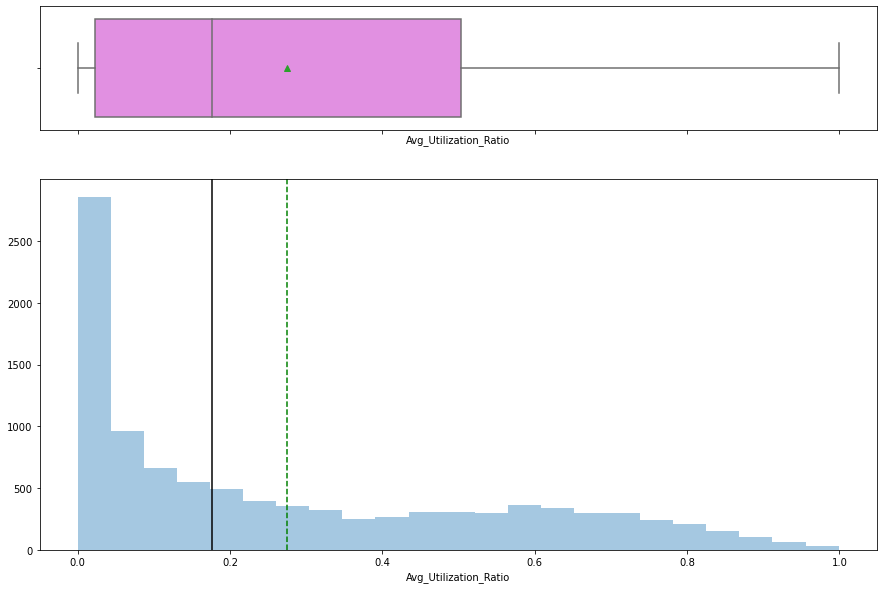

```python
histogram_boxplot(df['Avg_Utilization_Ratio'])
plt.savefig('Plt_AUR.png')
plt.show()
```

- The average utilization ratio is 0.27 with a media of 0.176. This accounts of rthe right skew curve.
- There are no outliers present

```python
# Function to create barplots that indicate percentage for each category.

def perc_on_bar(plot, feature):
    '''
    plot
    feature: categorical feature
    the function won't work if a column is passed in hue parameter
    '''

    total = len(feature) # length of the column
    for p in ax.patches:
        percentage = '{:.1f}%'.format(100 * p.get_height()/total) # percentage of each class of the category
        x = p.get_x() + p.get_width() / 2 - 0.05 # width of the plot
        y = p.get_y() + p.get_height()           # hieght of the plot
        ax.annotate(percentage, (x, y), size = 12) # annotate the percantage

    plt.show() # show the plot
```

### Observations on Attrition_Flag

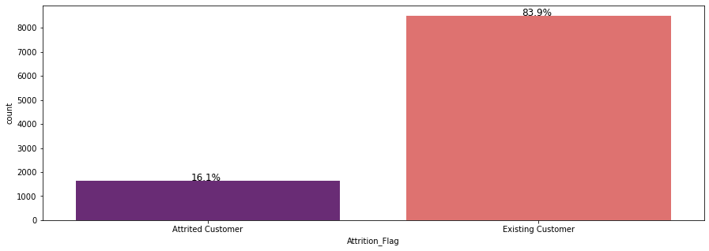

```python
plt.figure(figsize=(15,5))
ax = sns.countplot(df["Attrition_Flag"],palette='magma')
perc_on_bar(ax,df["Attrition_Flag"])
plt.savefig('Plt_AF.png')
plt.show()
```

- 83.9% of the customers are existing customers while just 16.1% attrited.

### Observations on Gender

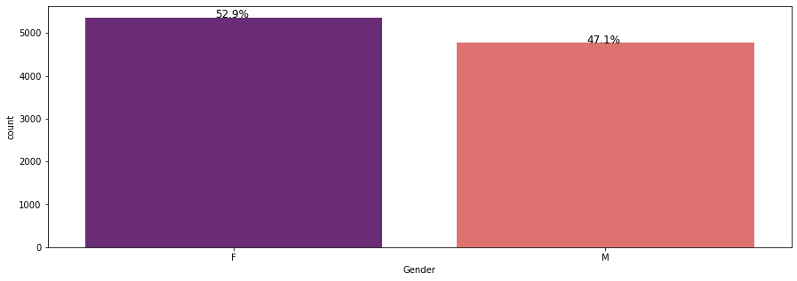

```python
plt.figure(figsize=(15,5))
ax = sns.countplot(df["Gender"],palette='magma')
perc_on_bar(ax,df["Gender"])
plt.savefig('Plt_G.png')
plt.show()
```

- 52.9% of customers in data are female while 47.1% are Male.

### Observations on Education_Level

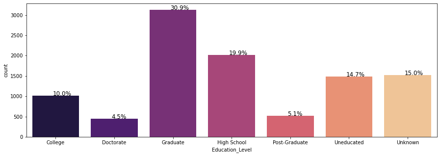

```python
plt.figure(figsize=(15,5))
ax = sns.countplot(df["Education_Level"],palette='magma')
perc_on_bar(ax,df["Education_Level"])
plt.savefig('Plt_EL.png')
plt.show()
```

- 30.9% of the Graduate customers trump the rest of the customer in other levels of Education
- The High school students follow next with the unknown and uneducated inching closely at 15.0% and 14.7% respectively.
- The least Educational levels are the Post-Graduate and Doctorate respectively

### Observations on Marital_Status

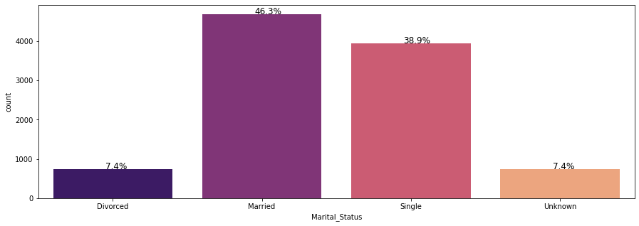

```python
plt.figure(figsize=(15,5))
ax = sns.countplot(df["Marital_Status"],palette='magma')
perc_on_bar(ax,df["Marital_Status"])
plt.savefig('Plt_MS.png')
plt.show()
```

- As can be inferred from the plot, 46.3% of the customers are married with Singles following closely at 38.9%
- Divorced and Unknown remain at par with 7.4%

### Observations on Income_Category

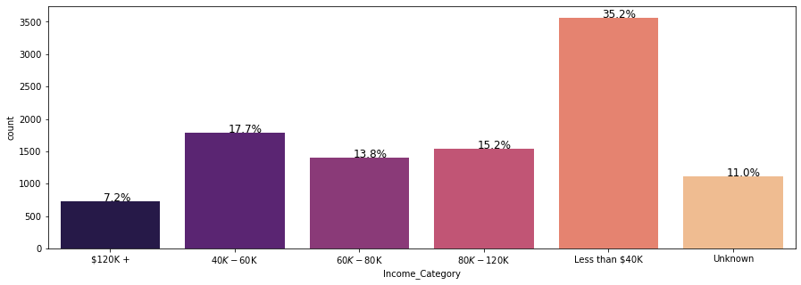

```python
plt.figure(figsize=(15,5))
ax = sns.countplot(df["Income_Category"],palette='magma')
perc_on_bar(ax,df["Income_Category"])
plt.savefig('Plt_IC.png')
plt.show()
```

- 35.2% of the customers earn less than 40k as well as 17.7% who earn between 40k-60k p.a
- 7.2% of the customers eanr the highest at 120k+ p.a followed closely by those who earn between 80k-120k

### Observations on Card_Category

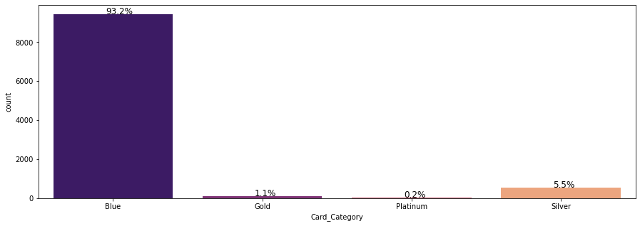

```python
plt.figure(figsize=(15,5))
ax = sns.countplot(df["Card_Category"],palette='magma')
perc_on_bar(ax,df["Card_Category"])
plt.savefig('Plt_CardC.png')
plt.show()
```

- The Blue Card_category enjoys the most subscription with about 93.2% of the distribution
- The Silver card comes at a distant second with 5.55 and Gold and Platinum respectively attracting the lowest patronage at 1.1% and 0.2%
- This is a clear indication of a lapse in targeted marketing campaign of potential prospects with capabilities

## Bivariate Analysis

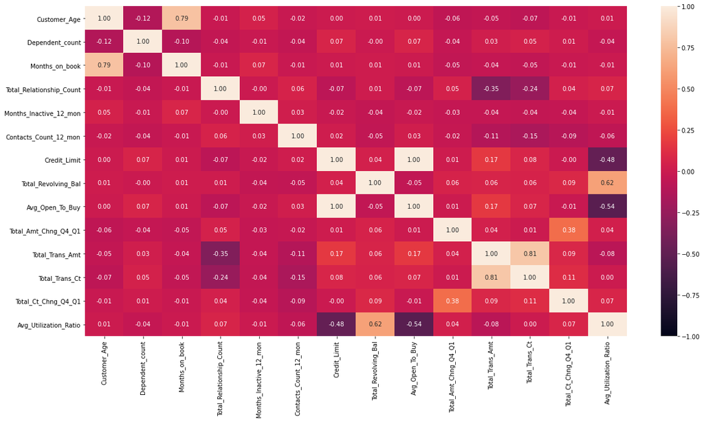

```python
plt.figure(figsize=(20,10))
sns.heatmap(df.corr(),annot=True,vmin=-1,vmax=1,fmt='.2f')
plt.savefig('Plt_Hm.png')
plt.show()
```

```python
#pair Plot to show visual correlation
#sns.pairplot(df, hue="Attrition_Flag")
#plt.savefig('Plt_PairPlt.png')
#plt.show()
```

### Attrition_Flag vs Education_Level vs Credit_Limit

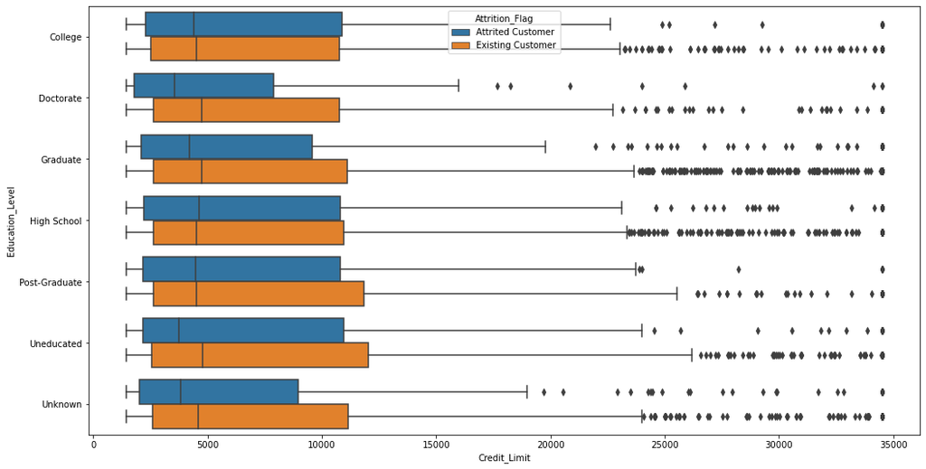

```python
plt.figure(figsize=(17,9))
sns.boxplot(y="Education_Level",x="Credit_Limit",data=df,hue='Attrition_Flag')
plt.savefig('TriPlt_ECA.png')
plt.show()
```